# Implementation of different activation functions

This is an example implementation of activation functions like Sigmoid, Hyperbolic Tangent Function (tanh) and Recitfied Linear Unit (ReLU).

#### Please bear in mind that these activation functions are to be applied to the outputs of hidden layers. Please apply Softmax to the output layer if it is a classification problem or a linear function otherwise.

### Import all necessary packages

```python
%matplotlib inline
%config InlineBackend.figure_format = 'retina'

import numpy as np
import matplotlib.pyplot as plt
import random
```

### Sigmoid and it's derivative

It takes a number and squashes it between 0 and 1. It can be thought of as an on/off state where 0 would mean that the neuron is off i.e. the neuron won't produce an output and 1 would mean that the neuron is on i.e. it will generate some output. However, SIgmoid suffers from vanishing gradient problem. Also, the output is not 0 centered.

#### Vanishing Gradient

When a neuron's output saturates either close to 0 or 1, the gradients at these regions is close to 0. During back propagation, if the local gradient is too small, it will make the gradient slowly vanish.

#### 0 Centering Problem

If the output is not 0 centered, the value of the function will be positive and that would make the weights of the gradient either all positive or all negative. This makes gradients go too far which makes optimization harder.

```python
def sigmoid(x):
    return 1 / (1 + np.exp(-x))

def sigmoid_derivative(x):
    return x * (1 - x)
```

### Hyperbolic Tangent Function (tanh) and it's derivative

It squashes the value between -1 and 1. Thus, the output is 0 centered which makes optimization easier. However, just like the sigmoid, it suffers from the vanishing gradient problem.

```python
def tanh(x):
    return np.tanh(x)

def tanh_derivative(x):
    return 1 - (x ** 2)
```

### Recitfied Linear Unit (ReLU) and it's derivative

```python
def relu(x):
    for i in range(0, len(x)):
        for k in range(0, len(x[i])):
            if x[i][k] > 0:
                pass  # do nothing since it would be effectively replacing x with x
            else:
                x[i][k] = 0
    return x

def relu_derivative(x):
    for i in range(0, len(x)):
        for k in range(len(x[i])):
            if x[i][k] > 0:
                x[i][k] = 1
            else:
                x[i][k] = 0
    return x
```

### Preparing all the inputs

```python
x = np.linspace(-25, 25)
```

### Sigmoid visualization

```
Sigmoid Visualization...
```

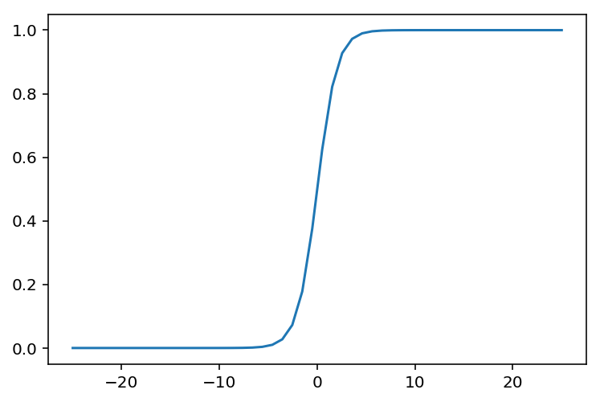

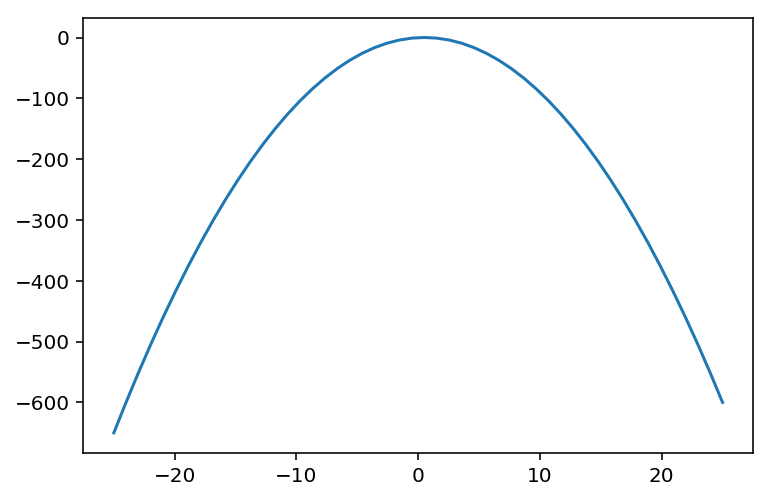

```python
print('Sigmoid Visualization...')

x_sigmoid = np.array(sigmoid(x))
x_sigmoid_derivative = np.array(sigmoid_derivative(x))

plt.plot(x, x_sigmoid)
plt.show()

plt.plot(x, x_sigmoid_derivative)
plt.show()
```

### tanh visualization

```
tanh Visualization...
```

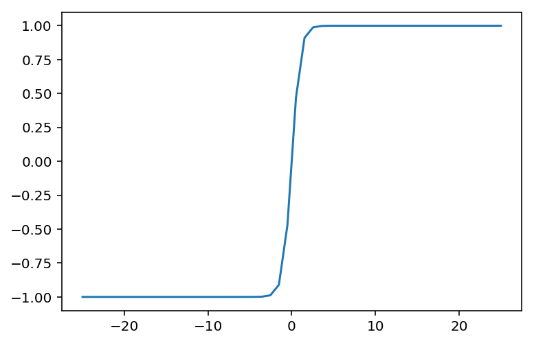

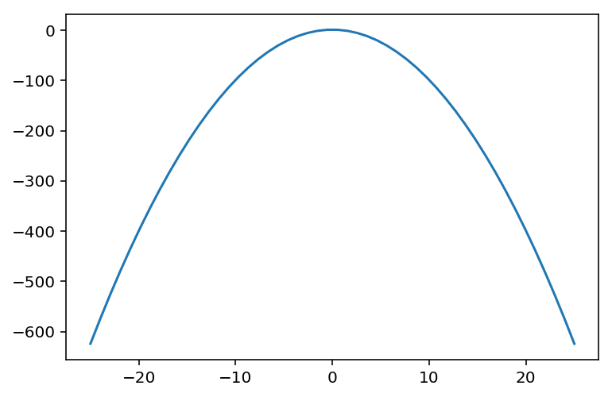

```python
print('tanh Visualization...')

x_tanh = tanh(x)
x_tanh_derivative = tanh_derivative(x)

plt.plot(x, x_tanh)
plt.show()

plt.plot(x, x_tanh_derivative)
plt.show()
```

### ReLU visualization

```
ReLU Visualization...
```

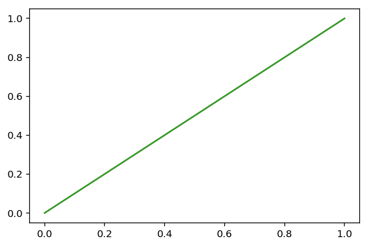

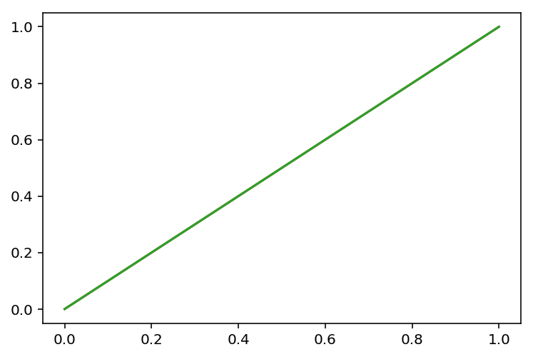

```python
print('ReLU Visualization...')

x = np.array([[-1, -2, -3], [1, 2, 3], [4, 5, 6]])

x_relu = relu(x)
x_relu_derivative = relu_derivative(x)

plt.plot(x, x_relu)
plt.show()

plt.plot(x, x_relu_derivative)
plt.show()
```